# Coffee Sales Forecast

Miruthula Vaishnavy S

# Assignment 4

**Questions Covered:** 1. Try the different models we ran in class on your dataset (2 points)  
2. Understand and explain your model output (4 points)  
3. Plot the time series and different model forecasts in one chart (2 points)  
4. Pick an accuracy measure, compare your models, and state the best model (2 points)

Dataset used: `Coffe_sales-2.csv`

# Load and Prepare the Data

turn daily transactions into one total value per day (daily sales).

```r
library(fpp2)
```

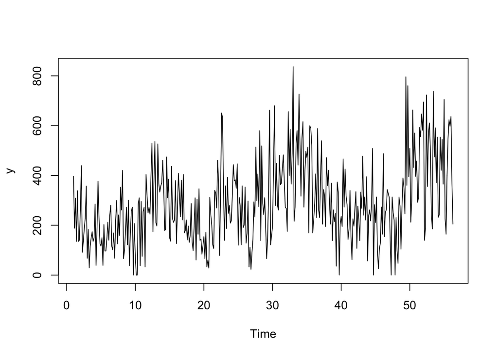

```r
library(TTR)

dat <- read.csv("Coffe_sales-2.csv", stringsAsFactors = FALSE)

# Minimal cleaning: Date to Date type, sum by day, fill gaps with 0
dat$Date <- as.Date(dat$Date)
daily <- aggregate(money ~ Date, data = dat, FUN = sum)
daily <- daily[order(daily$Date), ]

# fill missing calendar days so the series is regular
all_days <- data.frame(Date = seq(min(daily$Date), max(daily$Date), by = "day"))
daily <- merge(all_days, daily, by = "Date", all.x = TRUE)
daily$money[is.na(daily$money)] <- 0


y <- ts(daily$money, frequency = 7)
y[is.na(y)] <- 0
plot(y)
```

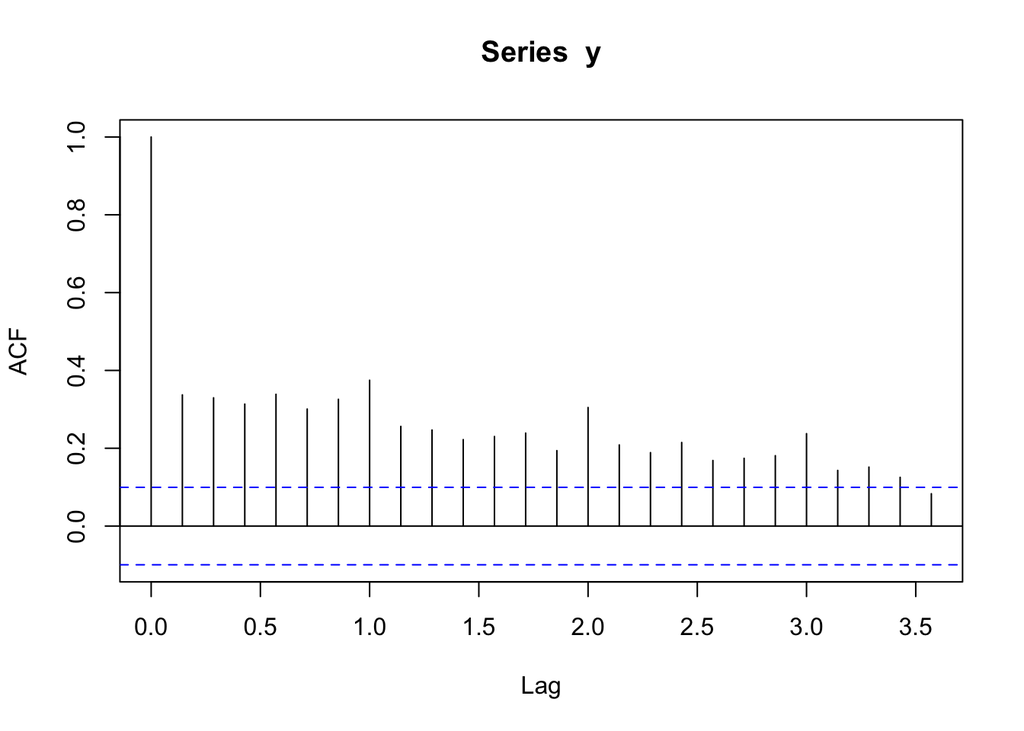

```r
acf(y)
```

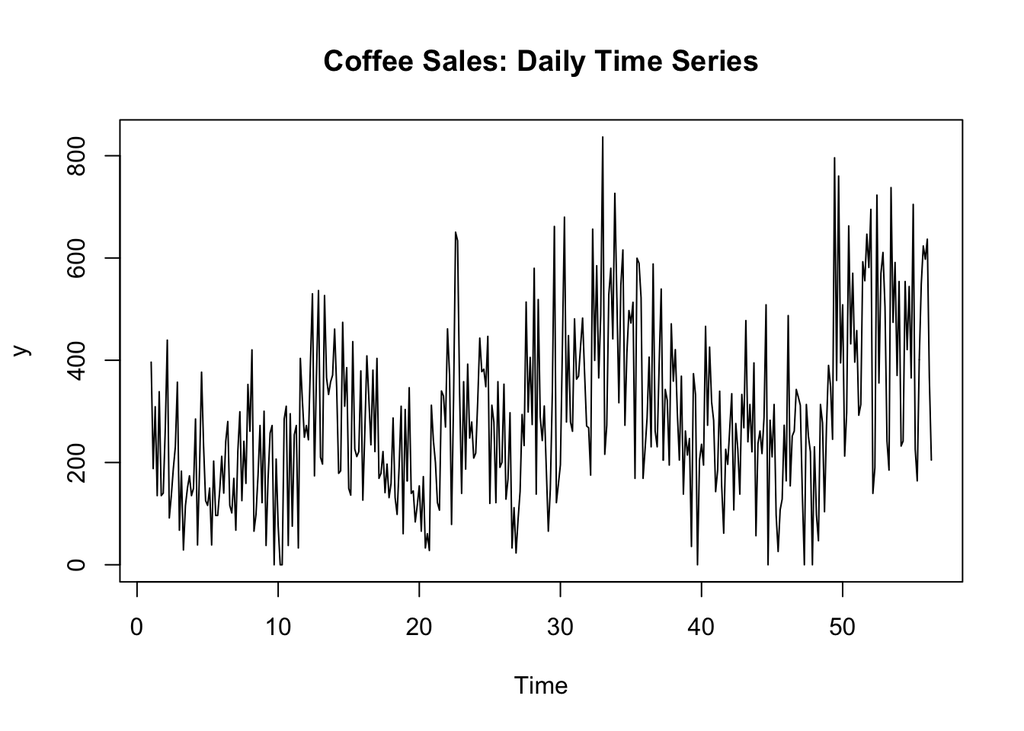

```r
h <- 15

plot(y, main= "Coffee Sales: Daily Time Series")
```

# Apply Forecasting Models

```r
# Mean
mean_forecast <- meanf(y, h)

# Naive
naive_forecast <- naive(y, h)

attributes(naive_forecast)
```

```
## $names
##  [1] "method"    "model"     "lambda"    "x"         "fitted"    "residuals"
##  [7] "series"    "mean"      "level"     "lower"     "upper"
##
## $class
## [1] "forecast"
```

```r
# Random Walk
rwf_forecast    <- rwf(y, h, drift = TRUE)

# Seasonal Naive
snaive_forecast <- snaive(y, h)

# Moving Averages

MA5  <- ma(y, order = 5)
MA9 <- ma(y,order=9)

# ETS
ets_forecast <- ets(y)

# HoltWinters
HW_forecast <- HoltWinters(y)

# Forecasts from ETS and HoltWinters
forecast_ets <- forecast(ets_forecast, h = h)
forecast_hw  <- forecast(HW_forecast,  h = h)
 ses_forecast      <- ses(y, h = h)
```

# Plot All Forecasts Together

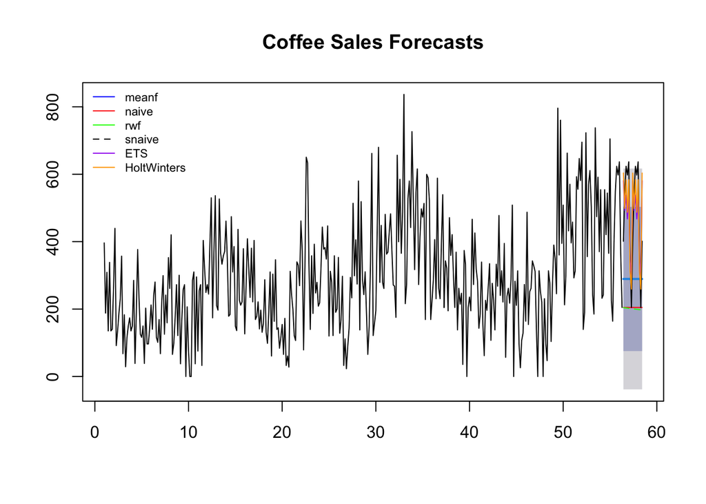

```r
plot(mean_forecast,main = "Coffee Sales Forecasts")
lines(naive_forecast$mean,        col = "red")
lines(rwf_forecast$mean,    col = "green", lty = 2)
lines(snaive_forecast$mean,       col = "black")
lines(forecast_ets$mean,          col = "purple")
lines(forecast_hw $mean,           col = "orange")
legend("topleft",
       c("meanf","naive","rwf","snaive","ETS","HoltWinters"),
       col = c("blue","red","green","black","purple","orange"),
       lty = c(1,1,1,2,1,1,1), bty = "n", cex = 0.7)
```

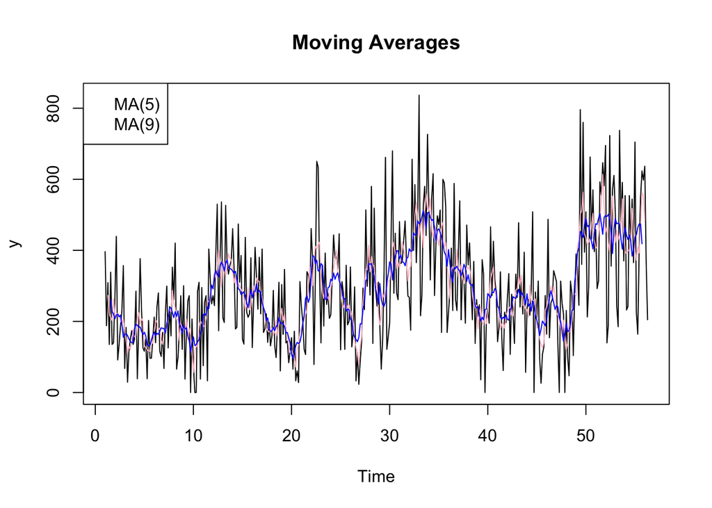

```r
# (3) Moving averages on history
plot(y, main = "Moving Averages")
lines(MA5, col = "pink")
lines(MA9, col = "blue")
legend("topleft", c("MA(5)","MA(9)"), col = c("pink","blue"))
```

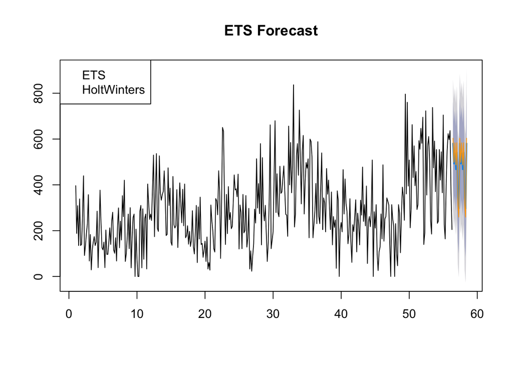

```r
# (4) ETS vs HoltWinters forecasts
plot(forecast_ets, main = "ETS Forecast")
lines(forecast_hw $mean, col = "orange")
legend("topleft", c("ETS","HoltWinters"), col = c("blue","orange"))
```

```r
attributes(naive_forecast)
```

```
## $names
##  [1] "method"    "model"     "lambda"    "x"         "fitted"    "residuals"
##  [7] "series"    "mean"      "level"     "lower"     "upper"
##
## $class
## [1] "forecast"
```

```r
ets_forecast$mse
```

```
## [1] 19725.28
```

```r
forecast_hw $SSE
```

[output not shown]

```r
head(HW_forecast$fitted)
```

```
## Time Series:
## Start = c(2, 1)
## End = c(2, 6)
## Frequency = 7
##              xhat    level     trend     season
## 2.000000 276.4267 230.7653 -1.271259   46.93265
## 2.142857 469.0157 227.9731 -1.275696  242.31837
## 2.285714 102.0912 222.5749 -1.287724 -119.19592
## 2.428571 116.6246 219.8268 -1.291984 -101.91020
## 2.571429 344.5973 221.1205 -1.284441  124.76122
## 2.714286  82.2649 198.0517 -1.347998 -114.43878
```

# Understand and Explain Your Model Output

**Mean Forecast** The mean forecast takes the average of all past coffee sales and predicts this same value for all future periods. It gives a flat line because it assumes no trend or seasonality.

**Naive Forecast** The naive model assumes that the next value equals the last observed value. It performs better than the mean forecast when data are stable, but it ignores trends and patterns.

**Random Walk** Similar to the naive model but allows a random step (or “drift”) between observations. It slightly adjusts forecasts up or down but doesn’t capture weekly patterns.

**Moving Average** The moving average smooths daily noise by taking the average of the past few days. It shows clearer sales trends and has the lowest RMSE, but it can’t predict future points—only smooth existing data.

**Seasonal Naive** Repeats the last week’s pattern. Works well when sales follow a weekly cycle, like daily coffee sales that peak on weekdays.

**SES (Simple Exponential Smoothing)** Gives more weight to recent observations. It smooths the series well but doesn’t handle trends or seasonality.

**Holt-Winters** Adds both trend and seasonality to Holt’s model. Captures the weekly pattern of coffee sales effectively and produces stable forecasts.

# Accuracy Comparison

```r
model_comparison <- rbind(
  MeanForecast   = accuracy(mean_forecast),
  Naive          = accuracy(naive_forecast),
  RandomWalk     = accuracy(rwf_forecast),
  MovingAverage  = accuracy(forecast(ma(y, order = 5), h = h)),
  SeasonalNaive  = accuracy(snaive_forecast),
  Holt           = accuracy(forecast_hw ),
  SES           = accuracy(ses_forecast)
)
```

```r
rownames(model_comparison) <- c("Mean Forecast", "Naive", "Random Walk",
                                "Moving Average", "Seasonal Naive",
                                "Holt", "SeS")

# Display only the main accuracy measures (rounded to 3 decimals)
round(model_comparison[, c("RMSE", "MAE", "MAPE", "MASE")], 3)
```

```
##                   RMSE     MAE   MAPE  MASE
## Mean Forecast  166.170 131.780    Inf 0.908
## Naive          191.440 151.558    Inf 1.045
## Random Walk    191.440 151.582    Inf 1.045
## Moving Average  37.666  29.873 11.608 0.409
## Seasonal Naive 183.878 145.069    Inf 1.000
## Holt           144.034 112.830    Inf 0.778
## SeS            144.464 115.261    Inf 0.795
```

# Pick an Accuracy Measure and State the Best Model

- Based on RMSE, the Moving Average gives the lowest error (37.666).
- However, since it only smooths past data and cannot forecast future values, it’s not ideal for prediction.
- The **Holt-Winters model** is the most practical forecasting model because it captures both trend and seasonality.
- It provides stable and realistic predictions for future coffee sales.